# Data analysis of laboratroy experiments on diploid and triploid pacific oysters

This is a notebook for the analysis of growth, motality, and oxygen consumption data from the single stressor experiments examining the impact of pH, temperature, and DO levels on pacific oysters.

# Packages

```r
library(tidyverse)
library(here)
library(survival)
library(ggfortify)
library(ggsurvfit)
library(survminer)
library(gridExtra)
library(frailtyEM)
library(lme4)
library(emmeans)
```

# Temperature

## Growth

Read in and prepare the data

```r
sizedat_temp <- read.csv(here("Data", "Temperature", "Size_Temperature.csv"))
sizedat_temp <- sizedat_temp %>%
  mutate(across(c("Treatment","Tank", "Ploidy", "Time", "Tag.colour", "Tag.num"), as.factor))
```

Plot the size distributions of each of the ploidy groups at the start and the end of the experiment

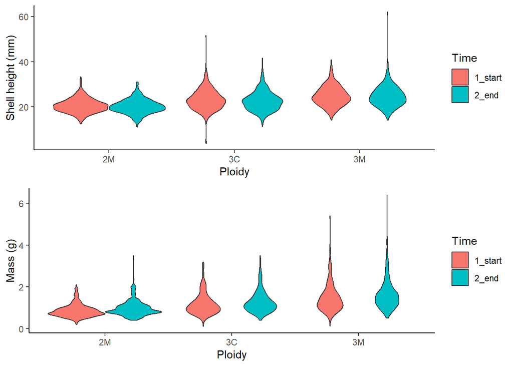

Conduct a linear mixed model to examine if there was a difference in the size of individuals at the start of the experiment and at the end. Will include each tank as a random factor. I will use the lme4 package for this.

Check the distribution of the data

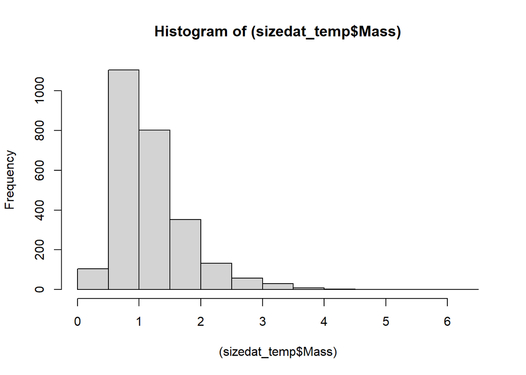

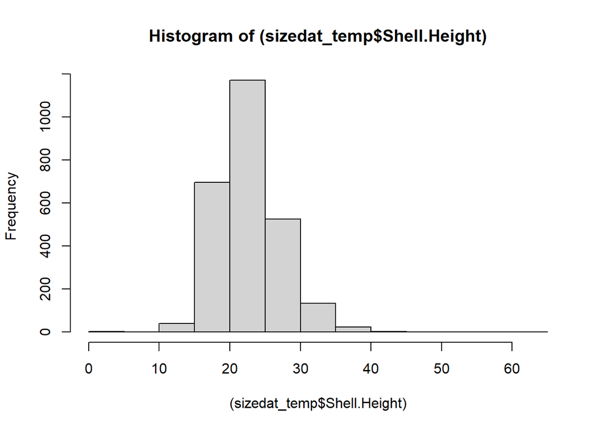

and the distribution of log transfomed data. Log transformed data is more normaly distrubuted so I am going to do the analyses on log transformed data.

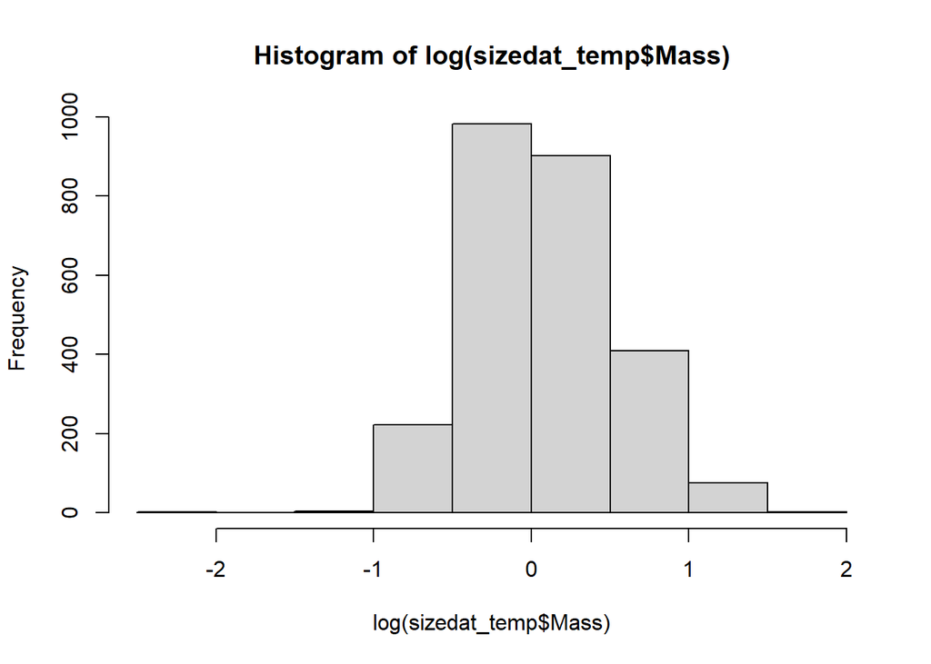

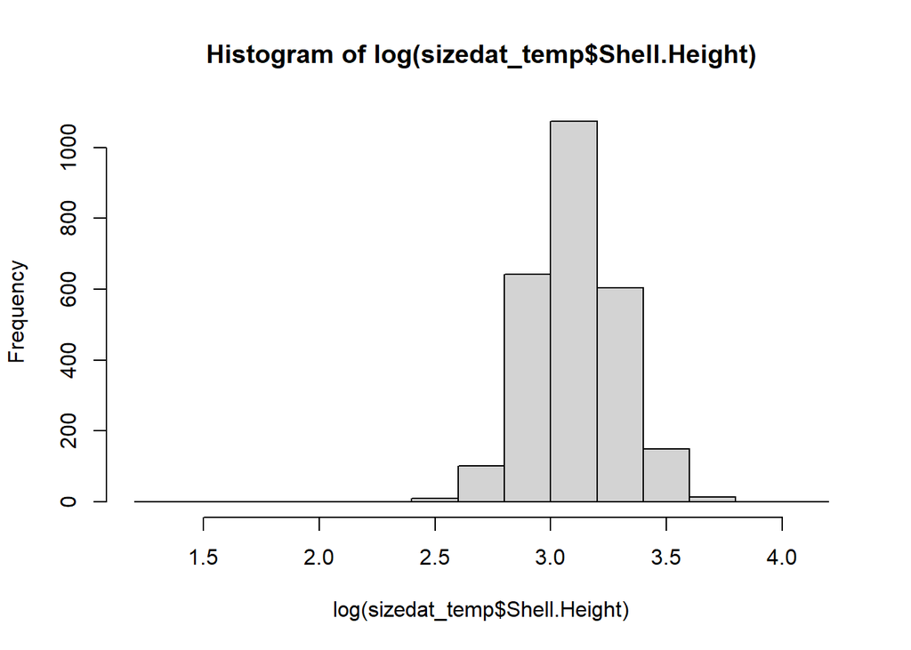

Develop the model for size and print the contrasts and p values using emmeans package. First I am going to examine growth in terms of total oyste mass. Tank is included as a random effect to account for any inter tank variation.

```r
massgrowthlme_temp <- lmer(log(Mass)~Ploidy*Time*Treatment+ (1|Tank), data = sizedat_temp) #This model includes a ransdom effect of tank.
emmeans_massgrowthlme_temp <- emmeans(massgrowthlme_temp, ~ Ploidy+Treatment+Time)
masscontrasts <- contrast(emmeans_massgrowthlme_temp)
masscontrastsdf <-  as.data.frame(masscontrasts)
print(masscontrastsdf %>% filter(p.value <=0.05))
```

```
##  contrast                          estimate         SE    df t.ratio p.value
##  2M Treatment7.5 1_start effect  -0.3884276 0.04950255 47.21  -7.847  <.0001
##  3C Treatment7.5 1_start effect  -0.1716049 0.05021577 49.89  -3.417  0.0020
##  3M Treatment7.5 1_start effect   0.1788513 0.04967055 47.85   3.601  0.0014
##  2M Treatment12.5 1_start effect -0.3030489 0.04938335 45.06  -6.137  <.0001
##  3M Treatment12.5 1_start effect  0.2469977 0.04922188 44.48   5.018  <.0001
##  2M Treatment17.5 1_start effect -0.3769448 0.04938335 45.06  -7.633  <.0001
##  3M Treatment17.5 1_start effect  0.1743955 0.04938335 45.06   3.531  0.0016
##  2M Treatment22.5 1_start effect -0.2596986 0.05126396 52.08  -5.066  <.0001
##  3M Treatment22.5 1_start effect  0.1791981 0.04821644 40.89   3.717  0.0012
##  2M Treatment27.5 1_start effect -0.2896725 0.04893699 47.43  -5.919  <.0001
##  3M Treatment27.5 1_start effect  0.1678607 0.04935342 46.48   3.401  0.0021
##  2M Treatment7.5 2_end effect    -0.2320860 0.05002532 49.23  -4.639  0.0001
##  3M Treatment7.5 2_end effect     0.3351401 0.05094969 52.93   6.578  <.0001
##  3M Treatment12.5 2_end effect    0.4290059 0.04989081 46.92   8.599  <.0001
##  2M Treatment17.5 2_end effect   -0.2547423 0.05024330 48.25  -5.070  <.0001
##  3C Treatment17.5 2_end effect    0.1198216 0.05006450 47.57   2.393  0.0282
##  3M Treatment17.5 2_end effect    0.2967377 0.05006456 47.57   5.927  <.0001
##  2M Treatment22.5 2_end effect   -0.1934548 0.05234097 56.48  -3.696  0.0011
##  3C Treatment22.5 2_end effect    0.1379697 0.05119480 51.96   2.695  0.0135
##  3M Treatment22.5 2_end effect    0.2693501 0.04926754 44.55   5.467  <.0001
##  2M Treatment27.5 2_end effect   -0.2395455 0.05040061 50.51  -4.753  <.0001
##  3M Treatment27.5 2_end effect    0.1814215 0.05116757 53.63   3.546  0.0015
##
## Degrees-of-freedom method: kenward-roger
## Results are given on the log (not the response) scale.
## P value adjustment: fdr method for 30 tests
```

```r
heightgrowthlme_temp <- lmer(Shell.Height~Ploidy*Time*Treatment + (1|Tank), data = filter(sizedat_temp))
```

The second step is to examine growth in terms of shell height.

```r
heightgrowthlme_temp <- lmer(log(Shell.Height)~Ploidy*Time*Treatment + (1|Tank), data = filter(sizedat_temp))
emmeans_heightgrowthlme_temp <- emmeans(heightgrowthlme_temp, ~ Ploidy+Treatment+Time)
heightcontrasts <- contrast(emmeans_heightgrowthlme_temp)
heightcontrasts <-  as.data.frame(heightcontrasts)#Change to a df so that I can filter out the results and only show p<0.05
print(heightcontrasts %>% filter(p.value <=0.05))
```

```
##  contrast                           estimate         SE    df t.ratio p.value
##  2M Treatment7.5 1_start effect  -0.10531354 0.02189973 63.48  -4.809  <.0001
##  3M Treatment7.5 1_start effect   0.11578969 0.02198332 64.45   5.267  <.0001
##  3M Treatment12.5 1_start effect  0.13324046 0.02174694 60.11   6.127  <.0001
##  2M Treatment17.5 1_start effect -0.12887091 0.02182733 61.00  -5.904  <.0001
##  3M Treatment17.5 1_start effect  0.07875590 0.02182733 61.00   3.608  0.0011
##  2M Treatment22.5 1_start effect -0.08995138 0.02275960 71.53  -3.952  0.0005
##  3C Treatment22.5 1_start effect  0.05703349 0.02174703 60.11   2.623  0.0166
##  3M Treatment22.5 1_start effect  0.07969503 0.02124467 54.62   3.751  0.0009
##  2M Treatment27.5 1_start effect -0.08485306 0.02165293 63.83  -3.919  0.0006
##  3M Treatment27.5 1_start effect  0.07920043 0.02182318 62.39   3.629  0.0011
##  2M Treatment7.5 2_end effect    -0.09779171 0.02215974 66.50  -4.413  0.0001
##  3M Treatment7.5 2_end effect     0.11461888 0.02261812 72.10   5.068  <.0001
##  2M Treatment12.5 2_end effect   -0.08625315 0.02226000 65.85  -3.875  0.0006
##  3M Treatment12.5 2_end effect    0.10894925 0.02207967 63.82   4.934  <.0001
##  2M Treatment17.5 2_end effect   -0.12871455 0.02225482 65.84  -5.784  <.0001
##  3M Treatment17.5 2_end effect    0.08186618 0.02216604 64.81   3.693  0.0009
##  2M Treatment22.5 2_end effect   -0.08972507 0.02329210 78.19  -3.852  0.0006
##  3M Treatment22.5 2_end effect    0.07128278 0.02176873 60.15   3.275  0.0029
##  2M Treatment27.5 2_end effect   -0.15514882 0.02234333 68.44  -6.944  <.0001
##  3C Treatment27.5 2_end effect   -0.05361250 0.02262688 71.91  -2.369  0.0293
##  3M Treatment27.5 2_end effect    0.06799760 0.02272355 73.14   2.992  0.0060
##
## Degrees-of-freedom method: kenward-roger
## Results are given on the log (not the response) scale.
## P value adjustment: fdr method for 30 tests
```

## Mortality

Read in the mortality data and prepare it for analysis

Now the the data is in the correct format I can ployt the mortality. Beacuse mortality was so low this will not be a very interesting plot. This shows pooled mortality across temperature treatments

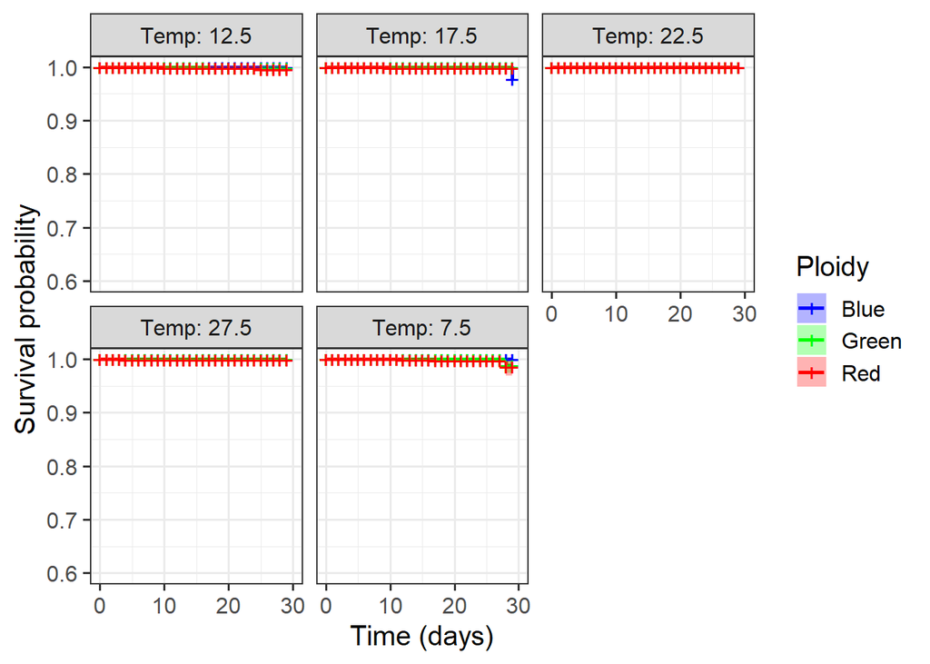

Plot the survival across tanks

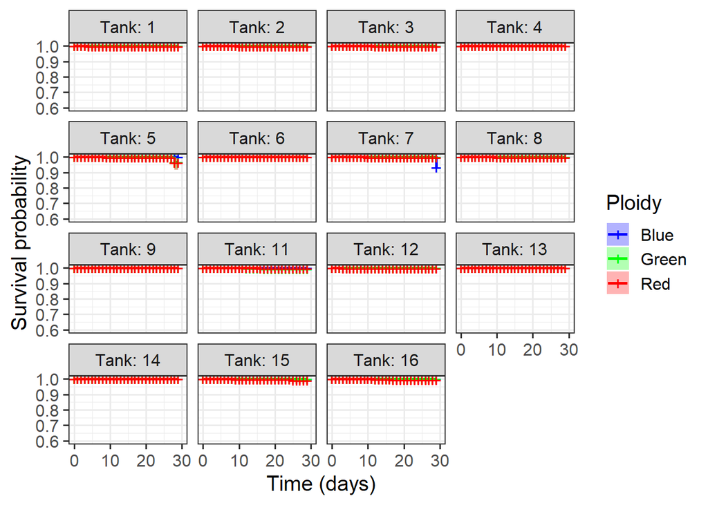

And finally the same plot, except faceted by Ploidy.

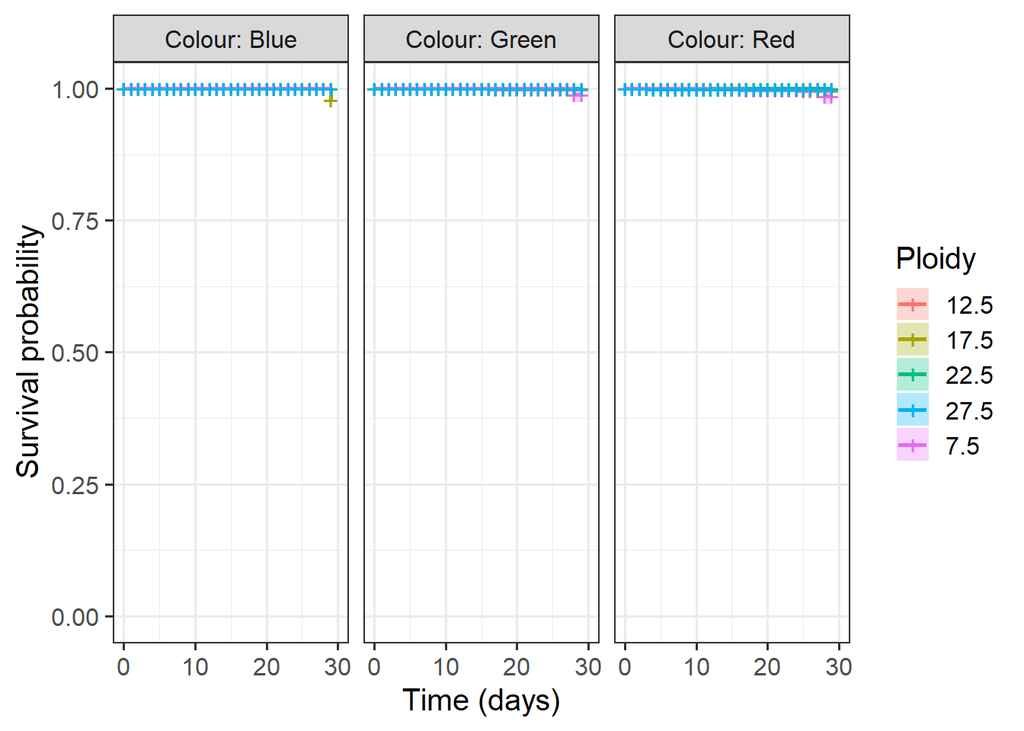

## Respiration

Read in the respiration data

```r
#make the rates column positive
```

## Mortality

Read in the mortality data and prepare it for analysis. This involves changing the data from being only number of moralities at each sampling event to giving each individual a status. This is a lot of code to do not very much

```
## [1] 250
```

### Plot the data to visualise mortality between tanks

This plot shows pooled survival across pH treatments. This does not account for any random effects of tank that could influence survival. Just a starting point to get an overview of the data.

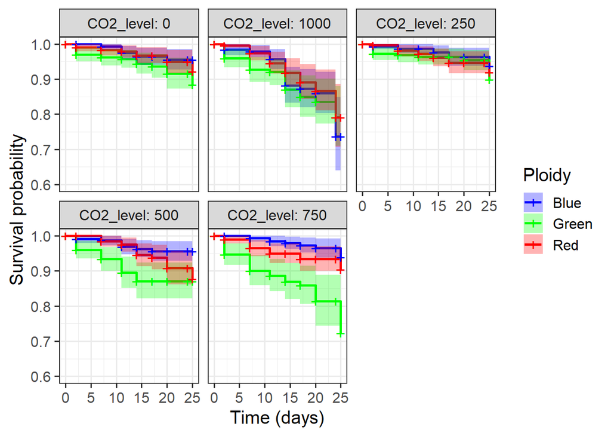

Here I am going to see how different ploidies reacted to the same pH treatment. The same data as above (i.e. pooled) but faceted by ploidy rather than CO2

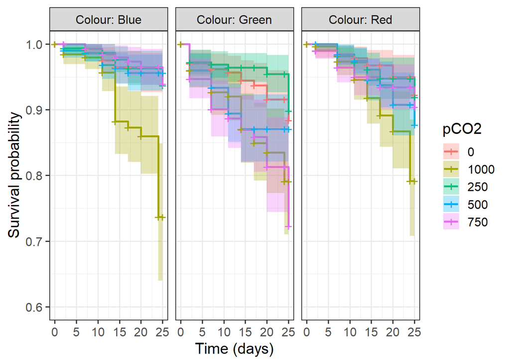

To see how survival varied across tanks this is a plot that shows the survival probability for each ploidy group across tanks.

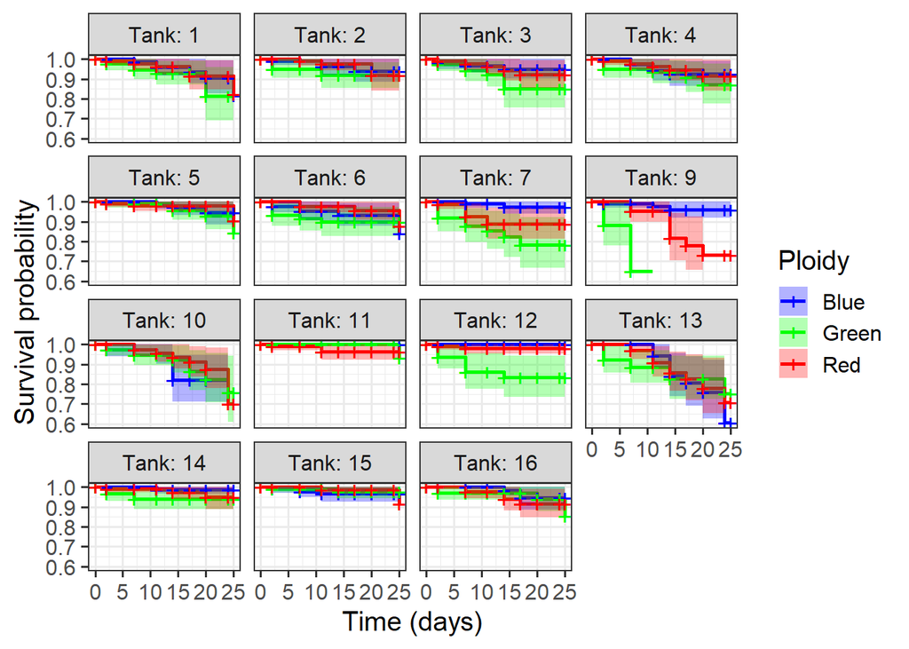

### Statistical analysis on the mortality data

First I am going to do a pooled analysis on all the data. This does not include a random effect of tank which I will include later. Using a cox proportional hazards model based on the analysis of McElhany.

```
## Call:
## coxph(formula = surv ~ CO2_level, data = survival_eventdat_pH)
##
##   n= 4880, number of events= 250
##
##                coef exp(coef)  se(coef)     z Pr(>|z|)
## CO2_level 0.0011390 1.0011396 0.0001864 6.109    1e-09 ***
## ---
## Signif. codes:  0 '***' 0.001 '**' 0.01 '*' 0.05 '.' 0.1 ' ' 1
##
##           exp(coef) exp(-coef) lower .95 upper .95
## CO2_level     1.001     0.9989     1.001     1.002
##
## Concordance= 0.596  (se = 0.019 )
## Likelihood ratio test= 38.55  on 1 df,   p=5e-10
## Wald test            = 37.32  on 1 df,   p=1e-09
## Score (logrank) test = 38.58  on 1 df,   p=5e-10
```

```
## Call:
## coxph(formula = surv ~ Colour, data = survival_eventdat_pH)
##
##   n= 4880, number of events= 250
##
##               coef exp(coef) se(coef)     z Pr(>|z|)
## ColourGreen 0.8294    2.2920   0.1583 5.240  1.6e-07 ***
## ColourRed   0.2774    1.3197   0.1694 1.638    0.101
## ---
## Signif. codes:  0 '***' 0.001 '**' 0.01 '*' 0.05 '.' 0.1 ' ' 1
##
##             exp(coef) exp(-coef) lower .95 upper .95
## ColourGreen     2.292     0.4363    1.6807     3.126
## ColourRed       1.320     0.7577    0.9469     1.839
##
## Concordance= 0.617  (se = 0.018 )
## Likelihood ratio test= 30.26  on 2 df,   p=3e-07
## Wald test            = 30.77  on 2 df,   p=2e-07
## Score (logrank) test = 32.15  on 2 df,   p=1e-07
```

```
## Call:
## coxph(formula = surv ~ Colour + CO2_level, data = survival_eventdat_pH)
##
##   n= 4880, number of events= 250
##
##                 coef exp(coef) se(coef)     z Pr(>|z|)
## ColourGreen 0.852969  2.346603 0.158292 5.389 7.10e-08 ***
## ColourRed   0.274628  1.316040 0.169397 1.621    0.105
## CO2_level   0.001159  1.001160 0.000185 6.264 3.75e-10 ***
## ---
## Signif. codes:  0 '***' 0.001 '**' 0.01 '*' 0.05 '.' 0.1 ' ' 1
##
##             exp(coef) exp(-coef) lower .95 upper .95
## ColourGreen     2.347     0.4261    1.7207     3.200
## ColourRed       1.316     0.7599    0.9442     1.834
## CO2_level       1.001     0.9988    1.0008     1.002
##
## Concordance= 0.654  (se = 0.019 )
## Likelihood ratio test= 70.71  on 3 df,   p=3e-15
## Wald test            = 70.61  on 3 df,   p=3e-15
## Score (logrank) test = 73.1  on 3 df,   p=9e-16
```

```
## Call:
## coxph(formula = surv ~ Colour * CO2_level, data = survival_eventdat_pH)
##
##   n= 4880, number of events= 250
##
##                             coef  exp(coef)   se(coef)      z Pr(>|z|)
## ColourGreen            1.0993187  3.0021199  0.3360112  3.272 0.001069 **
## ColourRed              0.5678293  1.7644329  0.3606251  1.575 0.115356
## CO2_level              0.0014913  1.0014924  0.0003922  3.802 0.000144 ***
## ColourGreen:CO2_level -0.0004002  0.9995999  0.0004772 -0.839 0.401614
## ColourRed:CO2_level   -0.0004765  0.9995236  0.0005133 -0.928 0.353303
## ---
## Signif. codes:  0 '***' 0.001 '**' 0.01 '*' 0.05 '.' 0.1 ' ' 1
##
##                       exp(coef) exp(-coef) lower .95 upper .95
## ColourGreen              3.0021     0.3331    1.5539     5.800
## ColourRed                1.7644     0.5668    0.8702     3.577
## CO2_level                1.0015     0.9985    1.0007     1.002
## ColourGreen:CO2_level    0.9996     1.0004    0.9987     1.001
## ColourRed:CO2_level      0.9995     1.0005    0.9985     1.001
##
## Concordance= 0.659  (se = 0.019 )
## Likelihood ratio test= 71.69  on 5 df,   p=5e-14
## Wald test            = 68.48  on 5 df,   p=2e-13
## Score (logrank) test = 76.95  on 5 df,   p=4e-15
```

I am going to add a random effect of tank here to assess inter tank variation. I am using the frailtyEM package (Balan and Putter 2019) as in McElhany crab survival analysis. I am going to include treatment and ploidy as fixed effects tank as a random effect. I have no idea if this is correct or how to interpret it.

```r
survival_eventdat_pH1 <- survival_eventdat_pH %>% mutate(across(c("CO2_level","Tank", "Colour"), as.factor))
survival_eventdat_pH1$Time <- as.numeric(survival_eventdat_pH1$Time)
survival_eventdat_pH1$Time <- survival_eventdat_pH1$Time+1
pH_frailty_fit <- survival_eventdat_pH1 %>% emfrail(Surv(Time, event, type = "right") ~ CO2_level*Colour + cluster(Tank),
distribution = emfrail_dist(dist = "gamma"),
data = .)
```